# Serialization benchmark: durability versus speed for MS objects

- Show All Code
- Hide All Code
- View Source

Round-trip cost and fidelity of saveRDS, qs2 and alabaster for Spectra objects

Authors

Philippine Louail

Johannes Rainer

Published

September 25, 2026

**Benchmark document of the doctoral thesis (thesis repository, `benchmarks/`):**

**Interoperable serialisation of mass spectrometry objects in R**

Philippine Louail<sup>1,2,*</sup>, Johannes Rainer<sup>1</sup>

<sup>1</sup> Institute for Biomedicine, Eurac Research, Bolzano, Italy <sup>2</sup> Chair for Bioinformatics, Friedrich-Schiller-University Jena, 07743 Jena, Germany

* Corresponding author: philippine.louail@outlook.com

> **Note on the environment.** `SpectraStash` requires the development `Spectra` (>= 1.23.2). To avoid disturbing a release-based installation, install the closure into a separate library, e.g. `install.packages(c("SpectraStash","MsStash","qs2","alabaster.base","MsBackendMetaboLights"),` `lib = "path/to/isolated/lib", dependencies = NA)` with the `rformassspectrometry` and `bioc` r-universe repositories, and point the environment variable `SERBENCH_LIB` at that library before rendering. Plotting additionally needs `ggplot2`, `tidyr` and `scales`.

> **Note on the data.** The benchmark serialises real spectra: the ten mzML files of the MetaboLights study MTBLS8735 (the *Metabonaut* plasma example), retrieved with `MsBackendMetaboLights`. That package keeps the files in the local `BiocFileCache`, so they are downloaded only on the first run.

> **Note on outputs.** Everything this document writes (the results tables, the session information and the figure) goes to the `results/` folder next to this file, and nowhere else. The serialised objects themselves are written to a temporary directory and discarded.

> **Note on the `alabaster` calls.** The `alabaster` `saveObject()` / `readObject()` methods for `Spectra` are provided by `SpectraStash`. The `xcms` axis below needs `xcmsStash`, which will provide the same methods for `xcms` results but is not yet released; those chunks are therefore set to `eval: false` and will run once `xcmsStash` is available.

## Motivation

Saving an analysis is not the same as being able to read it again in five years, on another machine, or from another language. R’s native serialisation (`saveRDS`) is fast and universal within R, but it is a binary, R-specific format that is explicitly discouraged for long-term archival: objects can fail to reload after an R upgrade, and S4 objects in particular can lose data *silently* when a class definition changes. For results that are meant to be deposited, shared, and re-read, durability and portability matter more than raw speed.

This document benchmarks three ways of persisting the central object type of the R for Mass Spectrometry ecosystem, a `Spectra` object (the same design applies to an `xcms` `XcmsExperiment`, see section 6), along two axes:

1. **Cost**: write time, read time, and on-disk size, as object size grows.
2. **Fidelity and durability**: whether the object round-trips *identically*, and whether the on-disk representation is language-agnostic and human-inspectable (the properties that make it survive version and toolchain changes).

The point is not that the language-agnostic `alabaster` format is fast (it is not) but that it occupies a different, and for FAIR data sharing more valuable, corner of the trade-off space than the binary formats.

## Methods under test

| Method | Package | Encoding | Language-agnostic | Human-readable / diff-able |
| --- | --- | --- | --- | --- |
| `saveRDS` | base R | binary (gzip) | no | no |
| `qs2` | `qs2` | binary (optimised) | no (R only) | no |
| `alabaster` | `alabaster.*` | HDF5 + JSON | yes | partly (JSON only) |

`fst`, `arrow`/`parquet` and `feather` are deliberately excluded from the round-trip comparison: they serialise flat, columnar tables rather than whole S4 objects, so they cannot persist a `Spectra` or `XcmsExperiment` container in one step. They are relevant only to the tabular *parts* of an object and are not benchmarked here.

```r
## Optional: point at an isolated library holding the development Spectra
## closure (see environment note above). Set SERBENCH_LIB to that path.
.serbench_lib <- Sys.getenv("SERBENCH_LIB")
if (nzchar(.serbench_lib) && dir.exists(.serbench_lib))
  .libPaths(c(.serbench_lib, .libPaths()))

.run_start <- Sys.time()

library(Spectra)
library(MsBackendMetaboLights)
library(SpectraStash)   # alabaster saveObject() / readObject() for Spectra
library(MsStash)
library(qs2)
library(alabaster.base)
library(BiocParallel)
library(ggplot2)
library(tidyr)
library(dplyr)

## Loaded only if available (the xcms axis is optional)
.have_xcms <- requireNamespace("xcms", quietly = TRUE) &&
  requireNamespace("xcmsStash", quietly = TRUE)

## All outputs of this document go to results/ next to the .qmd, and nowhere
## else. Quarto knits with the working directory set to the document's folder;
## knitr::current_input() pins it down when the file is run some other way.
.doc_dir <- tryCatch(dirname(knitr::current_input(dir = TRUE)),
                     error = function(e) getwd())
if (!length(.doc_dir) || is.na(.doc_dir)) .doc_dir <- getwd()
res_dir <- file.path(.doc_dir, "results")
dir.create(res_dir, showWarnings = FALSE, recursive = TRUE)
if (!dir.exists(res_dir))
  stop("Could not create the results directory '", res_dir, "'.")

## Fixed order, one entry per format: colour, point shape and line type.
## Binary formats are drawn solid, the language-agnostic one dashed.
method_levels <- c("saveRDS", "qs2", "alabaster")
method_colours <- c(
  "saveRDS"   = "#2a78d6",
  "qs2"       = "#eb6834",
  "alabaster" = "#1baf7a"
)
method_shapes <- c("saveRDS" = 16, "qs2" = 17, "alabaster" = 15)
method_linetypes <- c("saveRDS" = "solid", "qs2" = "solid",
                      "alabaster" = "dashed")

# Directory size helper (bytes): a method may write a file or a directory
path_size <- function(p) {
  if (dir.exists(p))
    sum(file.info(list.files(p, recursive = TRUE, full.names = TRUE))$size,
        na.rm = TRUE)
  else file.info(p)$size
}
```

## System information

The machine the benchmark ran on; the full `sessionInfo()` is at the end of the document and is also written to `results/serialization_sessionInfo.txt`.

```r
.first_line <- function(x) {
  x <- trimws(x[nzchar(trimws(x))])
  if (length(x)) x[1L] else NA_character_
}
cpu_model <- function() {
  tryCatch(switch(Sys.info()[["sysname"]],
    Windows = .first_line(system2("powershell", c("-NoProfile", "-Command",
      shQuote("(Get-CimInstance Win32_Processor).Name", type = "cmd")), stdout = TRUE)),
    Darwin = .first_line(system2("sysctl", c("-n", "machdep.cpu.brand_string"),
                                 stdout = TRUE)),
    Linux = sub(".*: ", "", .first_line(grep("model name",
      readLines("/proc/cpuinfo"), value = TRUE))),
    NA_character_), error = function(e) NA_character_)
}
ram_gb <- function(what = c("total", "free")) {
  what <- match.arg(what)
  tryCatch(switch(Sys.info()[["sysname"]],
    Windows = {
      prop <- if (what == "total") "TotalVisibleMemorySize" else "FreePhysicalMemory"
      round(as.numeric(.first_line(system2("powershell", c("-NoProfile",
        "-Command", shQuote(paste0("(Get-CimInstance Win32_OperatingSystem).",
                                   prop), type = "cmd")), stdout = TRUE))) / 1024^2, 1)
    },
    Linux = {
      key <- if (what == "total") "MemTotal" else "MemAvailable"
      l <- grep(key, readLines("/proc/meminfo"), value = TRUE)
      round(as.numeric(gsub("[^0-9]", "", l)) / 1024^2, 1)
    },
    NA_real_), error = function(e) NA_real_)
}
sys_info <- data.frame(
  Property = c("Date of run", "CPU", "Logical cores", "RAM total (GB)",
               "RAM free at start (GB)", "OS", "R version", "Platform",
               "Serialisation target (tempdir)"),
  Value = c(format(.run_start, "%Y-%m-%d %H:%M %Z"), cpu_model(),
            as.character(parallel::detectCores()),
            as.character(ram_gb("total")), as.character(ram_gb("free")),
            utils::osVersion, R.version$version.string, R.version$platform,
            tempdir()))
for (pkg in c("Spectra", "MsBackendMetaboLights", "SpectraStash", "MsStash",
              "qs2", "alabaster.base", "xcms", "xcmsStash")) {
  if (requireNamespace(pkg, quietly = TRUE))
    sys_info <- rbind(sys_info, data.frame(
      Property = paste(pkg, "version"),
      Value = as.character(packageVersion(pkg))))
}
knitr::kable(sys_info, caption = "System information")
```

System information

| Property | Value |
| --- | --- |
| Date of run | 2026-09-25 16:03 CEST |
| CPU | 13th Gen Intel(R) Core(TM) i7-13700H |
| Logical cores | 20 |
| RAM total (GB) | 31.8 |
| RAM free at start (GB) | 21.6 |
| OS | Windows 11 x64 (build 26200) |
| R version | R version 4.6.0 (2026-04-24 ucrt) |
| Platform | x86_64-w64-mingw32 |
| Serialisation target (tempdir) | C: |
| Spectra version | 1.23.3 |
| MsBackendMetaboLights version | 1.7.4 |
| SpectraStash version | 0.97.6 |
| MsStash version | 0.99.0 |
| qs2 version | 0.2.2 |
| alabaster.base version | 1.13.1 |
| xcms version | 4.11.1 |

## 1. Test objects

We serialise real LC–HRMS data: the ten mzML files of the positive-mode HILIC assay of MetaboLights study MTBLS8735 (the *Metabonaut* plasma example, four QC pools and six plasma samples). `MsBackendMetaboLights` resolves the files through the local `BiocFileCache`: it first looks for them offline and only contacts MetaboLights (and downloads what is missing) if they are not cached. The spectra are then moved into memory with `setBackend(MsBackendMemory())`, so that every format serialises the same fully realised object, peaks included.

```r
mtbls_id    <- "MTBLS8735"
mtbls_assay <- "a_MTBLS8735_LC-MS_positive_hilic_metabolite_profiling.txt"
.t_load <- Sys.time()
sps_full <- tryCatch(
  Spectra(source = MsBackendMetaboLights(), mtblsId = mtbls_id,
          assayName = mtbls_assay, filePattern = "mzML$", offline = TRUE),
  error = function(e)
    Spectra(source = MsBackendMetaboLights(), mtblsId = mtbls_id,
            assayName = mtbls_assay, filePattern = "mzML$"))
sps_full <- setBackend(sps_full, MsBackendMemory(), BPPARAM = SerialParam())
.t_load <- difftime(Sys.time(), .t_load, units = "secs")

n_peaks_per_spectrum <- lengths(sps_full)
knitr::kable(data.frame(
  Property = c("Data files", "Spectra", "MS levels", "Peaks (total)",
               "Peaks per spectrum (median)", "In-memory size (MB)",
               "Load + setBackend time (s)"),
  Value = c(length(unique(dataOrigin(sps_full))), length(sps_full),
            paste(sort(unique(msLevel(sps_full))), collapse = ", "),
            format(sum(n_peaks_per_spectrum), big.mark = ","),
            median(n_peaks_per_spectrum),
            round(as.numeric(object.size(sps_full)) / 1e6, 1),
            round(as.numeric(.t_load), 1))),
  caption = "The MTBLS8735 test data")
```

The MTBLS8735 test data

| Property | Value |
| --- | --- |
| Data files | 10 |
| Spectra | 17210 |
| MS levels | 1 |
| Peaks (total) | 67,469,888 |
| Peaks per spectrum (median) | 4145.5 |
| In-memory size (MB) | 1094.1 |
| Load + setBackend time (s) | 65.6 |

The benchmark serialises nested subsets of increasing size: the first 500, 2,000, 5,000 and 8,000 spectra, and all spectra. Files are kept in their cache order, so the smaller subsets cover the first sample files.

```r
## SERBENCH_QUICK=1 runs a fast smoke grid; otherwise the full grid.
n_grid <- if (nzchar(Sys.getenv("SERBENCH_QUICK"))) c(200, 500) else
  c(500, 2000, 5000, 8000, length(sps_full))
n_grid <- sort(unique(pmin(n_grid, length(sps_full))))
spectra_at <- function(n)
  if (n >= length(sps_full)) sps_full else sps_full[seq_len(n)]
n_grid
```

```
[1]   500  2000  5000  8000 17210
```

For the `xcms` axis (via `xcmsStash`, not yet released, hence `eval: false`) one would run a standard centWave preprocessing on a subset of files and grow the object by the number of samples retained.

```r
library(xcms)
mzml_files <- unique(dataOrigin(sps_full))
# Use a manageable number of files for the preprocessing example
xf <- readMsExperiment(spectraFiles = head(mzml_files, 6))
cwp <- CentWaveParam(peakwidth = c(2, 20), ppm = 25, noise = 1000)
xdata <- findChromPeaks(xf, param = cwp)
# Grow by subsetting the number of files retained in the object
xcms_grid <- seq_len(length(fileNames(xdata)))
xcms_at <- function(k) xdata[, seq_len(k)]  # column = sample
```

## 2. Methods under test (wrapper functions)

Each method is a pair of `write(obj, path)` / `read(path)` closures plus the path it writes to. Keeping them behind a common interface lets the harness stay serializer-agnostic.

```r
methods_spectra <- list(
  saveRDS = list(
    write = function(o, p) saveRDS(o, p),
    read  = function(p) readRDS(p),
    path  = function(d) file.path(d, "obj.rds")),
  qs2 = list(
    write = function(o, p) qs2::qs_save(o, p),
    read  = function(p) qs2::qs_read(p),
    path  = function(d) file.path(d, "obj.qs2")),
  alabaster = list(
    write = function(o, p) { unlink(p, recursive = TRUE)
                             alabaster.base::saveObject(o, p) },
    read  = function(p) alabaster.base::readObject(p),
    path  = function(d) file.path(d, "obj_alabaster"))
)
```

> For an in-memory backend, `SpectraStash` stores the `alabaster` peaks (m/z and intensity matrices) in one HDF5 file and the spectra variables as HDF5/JSON, and reloads the object into an `MsBackendMemory`. As for `saveRDS` and `qs2`, every read time below therefore includes loading all peaks into memory. Where a method fails on an object, the failure is recorded in the `error` column rather than hidden.

## 3. Cost benchmark: write time, read time, on-disk size

```r
tmp <- tempfile("serbench"); dir.create(tmp)

## Wall-clock timing over several iterations. We deliberately avoid bench::mark()
## here: its memory profiling is pathologically slow for methods that write
## many files (alabaster). Instead each write and each read is timed
## `reps` times and reported as mean and standard deviation, so the run-to-run
## variability is visible as error bars in the plots below.
time_it <- function(expr) {
  t0 <- proc.time()[["elapsed"]]; force(expr); proc.time()[["elapsed"]] - t0
}
reps <- if (nzchar(Sys.getenv("SERBENCH_QUICK"))) 2L else 5L
bench_one <- function(obj, methods, n, reps = 5L) {
  out <- lapply(names(methods), function(m) {
    mm <- methods[[m]]; p <- mm$path(tmp); err <- NA_character_
    .err <- function(e) { err <<- conditionMessage(e); NULL }
    ## one untimed warm-up run absorbs cold-start effects (disk cache, GC),
    ## then take `reps` timed runs and summarise as mean and SD.
    tryCatch(mm$write(obj, p), error = .err)
    wts <- tryCatch(replicate(reps, time_it(mm$write(obj, p))),
                    error = function(e) { .err(e); rep(NA_real_, reps) })
    sz <- tryCatch(path_size(p), error = function(e) NA_real_)
    tryCatch(invisible(mm$read(p)), error = .err)
    rts <- tryCatch(replicate(reps, time_it(mm$read(p))),
                    error = function(e) { .err(e); rep(NA_real_, reps) })
    gc()
    data.frame(method = m, n_spectra = n, n_peaks = if (is(obj, "Spectra")) sum(lengths(obj)) else NA_real_,
               object_MB = as.numeric(object.size(obj)) / 1e6, reps = reps,
               write_s = mean(wts), write_sd = sd(wts),
               read_s  = mean(rts), read_sd  = sd(rts),
               bytes = sz, MB = sz / 1e6,
               write_runs_s = paste(signif(wts, 5), collapse = ";"),
               read_runs_s  = paste(signif(rts, 5), collapse = ";"),
               error = err)
  })
  do.call(rbind, out)
}

.t_bench <- Sys.time()
res_spectra <- do.call(rbind, lapply(n_grid, function(n) {
  r <- bench_one(spectra_at(n), methods_spectra, n, reps = reps)
  gc()
  r
}))
.t_bench <- difftime(Sys.time(), .t_bench, units = "mins")
res_spectra$method <- factor(res_spectra$method, levels = method_levels)

write.csv(res_spectra, file.path(res_dir, "serialization_cost.csv"),
          row.names = FALSE)
knitr::kable(res_spectra[, c("method", "n_spectra", "n_peaks", "object_MB",
                             "write_s", "write_sd", "read_s", "read_sd", "MB")],
             digits = 3,
             caption = paste0("Spectra: serialisation cost by object size (mean ",
                              "and SD of ", reps, " timed runs after one ",
                              "warm-up; MB = bytes / 1e6). The complete table, ",
                              "with the individual runs, is in ",
                              "results/serialization_cost.csv."))
```

Spectra: serialisation cost by object size (mean and SD of 5 timed runs after one warm-up; MB = bytes / 1e6). The complete table, with the individual runs, is in results/serialization_cost.csv.

| method | n_spectra | n_peaks | object_MB | write_s | write_sd | read_s | read_sd | MB |
| --- | --- | --- | --- | --- | --- | --- | --- | --- |
| saveRDS | 500 | 1385615 | 22.631 | 1.006 | 0.050 | 0.162 | 0.019 | 15.715 |
| qs2 | 500 | 1385615 | 22.631 | 0.132 | 0.023 | 0.046 | 0.005 | 15.372 |
| alabaster | 500 | 1385615 | 22.631 | 2.856 | 0.145 | 0.440 | 0.033 | 19.302 |
| saveRDS | 2000 | 7590324 | 123.244 | 5.256 | 0.048 | 0.834 | 0.018 | 85.405 |
| qs2 | 2000 | 7590324 | 123.244 | 0.716 | 0.032 | 0.266 | 0.041 | 82.517 |
| alabaster | 2000 | 7590324 | 123.244 | 12.216 | 0.486 | 1.598 | 0.359 | 103.096 |
| saveRDS | 5000 | 19090884 | 309.773 | 12.748 | 0.387 | 2.218 | 0.136 | 214.324 |
| qs2 | 5000 | 19090884 | 309.773 | 1.556 | 0.041 | 0.602 | 0.057 | 207.192 |
| alabaster | 5000 | 19090884 | 309.773 | 28.154 | 0.651 | 3.778 | 0.295 | 259.059 |
| saveRDS | 8000 | 30408547 | 493.377 | 21.096 | 0.171 | 3.710 | 0.165 | 341.467 |
| qs2 | 8000 | 30408547 | 493.377 | 2.844 | 0.167 | 1.100 | 0.056 | 329.733 |
| alabaster | 8000 | 30408547 | 493.377 | 44.066 | 1.155 | 5.562 | 0.354 | 412.744 |
| saveRDS | 17210 | 67469888 | 1094.096 | 42.160 | 0.388 | 6.988 | 0.094 | 756.751 |
| qs2 | 17210 | 67469888 | 1094.096 | 5.166 | 0.035 | 2.132 | 0.346 | 731.282 |
| alabaster | 17210 | 67469888 | 1094.096 | 84.696 | 0.453 | 11.950 | 0.305 | 913.834 |

At the largest size (17,210 spectra) the formats compare as follows; the timing loop took 30.9 minutes.

```r
.pm <- function(m, s) sprintf("%.2f ± %.2f", m, s)
top <- res_spectra[res_spectra$n_spectra == max(n_grid), ]
knitr::kable(data.frame(
  format = top$method,
  `write (s)` = .pm(top$write_s, top$write_sd),
  `read (s)` = .pm(top$read_s, top$read_sd),
  `on disk (MB)` = round(top$MB, 1),
  `write vs qs2` = round(top$write_s / top$write_s[top$method == "qs2"], 1),
  `size vs qs2` = round(top$MB / top$MB[top$method == "qs2"], 2),
  check.names = FALSE),
  caption = "Headline numbers at the largest object size (mean ± SD)")
```

Headline numbers at the largest object size (mean ± SD)

| format | write (s) | read (s) | on disk (MB) | write vs qs2 | size vs qs2 |
| --- | --- | --- | --- | --- | --- |
| saveRDS | 42.16 ± 0.39 | 6.99 ± 0.09 | 756.8 | 8.2 | 1.03 |
| qs2 | 5.17 ± 0.04 | 2.13 ± 0.35 | 731.3 | 1.0 | 1.00 |
| alabaster | 84.70 ± 0.45 | 11.95 ± 0.31 | 913.8 | 16.4 | 1.25 |

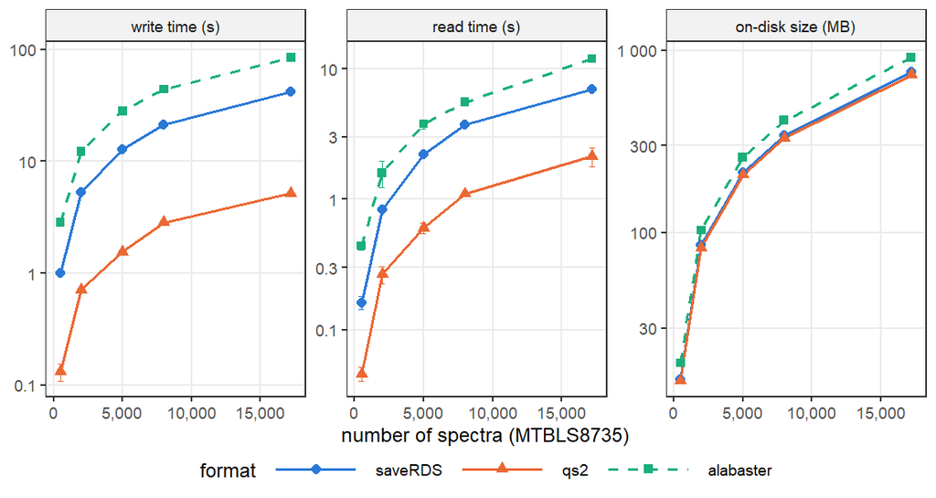

```r
## Long format carrying, per metric, the value and its SD (size has no SD).
res_long <- rbind(
  data.frame(method = res_spectra$method, n = res_spectra$n_spectra,
             metric = "write time (s)", value = res_spectra$write_s,
             sd = res_spectra$write_sd),
  data.frame(method = res_spectra$method, n = res_spectra$n_spectra,
             metric = "read time (s)", value = res_spectra$read_s,
             sd = res_spectra$read_sd),
  data.frame(method = res_spectra$method, n = res_spectra$n_spectra,
             metric = "on-disk size (MB)", value = res_spectra$MB,
             sd = NA_real_))
res_long$metric <- factor(res_long$metric,
  levels = c("write time (s)", "read time (s)", "on-disk size (MB)"))
res_long$method <- factor(res_long$method, levels = method_levels)
## Error bars are mean +/- SD; on a log axis a lower end at or below zero cannot
## be drawn, so such a bar is omitted rather than clipped.
res_long$ymin <- ifelse(res_long$value - res_long$sd > 0,
                        res_long$value - res_long$sd, NA_real_)
res_long$ymax <- res_long$value + res_long$sd

## The filled square looks larger than the other symbols, so it is drawn smaller.
method_sizes <- c("saveRDS" = 1.8, "qs2" = 1.8, "alabaster" = 1.6)
p_cost <- ggplot(res_long, aes(n, value, colour = method, shape = method,
                               linetype = method)) +
  geom_errorbar(aes(ymin = ymin, ymax = ymax),
                width = 0.025 * diff(range(res_long$n)), linewidth = 0.35,
                linetype = "solid", na.rm = TRUE, show.legend = FALSE) +
  geom_line(linewidth = 0.6) +
  geom_point(aes(size = method)) +
  facet_wrap(~metric, scales = "free_y", nrow = 1) +
  scale_y_log10(breaks = scales::breaks_log(n = 6),
                labels = scales::label_number(drop0trailing = TRUE)) +
  scale_x_continuous(labels = scales::label_comma()) +
  scale_colour_manual(values = method_colours, breaks = method_levels) +
  scale_shape_manual(values = method_shapes, breaks = method_levels) +
  scale_linetype_manual(values = method_linetypes, breaks = method_levels) +
  scale_size_manual(values = method_sizes, breaks = method_levels) +
  ## One merged legend whose keys show colour, symbol AND line type.
  guides(colour = guide_legend(nrow = 1, override.aes = list(
    linetype = unname(method_linetypes[method_levels]),
    shape = unname(method_shapes[method_levels]),
    size = unname(method_sizes[method_levels]),
    linewidth = 0.6))) +
  labs(x = "number of spectra (MTBLS8735)", y = NULL, colour = "format",
       shape = "format", linetype = "format", size = "format") +
  theme_bw(base_size = 9) +
  theme(legend.position = "bottom",
        legend.key.width = unit(1.6, "cm"),
        legend.margin = margin(0, 0, 0, 0),
        legend.box.spacing = unit(2, "pt"),
        panel.grid.minor = element_blank(),
        strip.background = element_rect(fill = "grey95"))
p_cost
```

```r
## Persist the figure next to the tables: rendering the qmd regenerates it.
## (Timings are wall-clock, so absolute values vary run to run.)
ggsave(file.path(res_dir, "serialization_cost.png"), p_cost,
       width = 15, height = 8, units = "cm", dpi = 300)
```

## 4. Fidelity: does the object round-trip identically?

Speed is meaningless if the reloaded object is not the same object. For each method we write and reload the first 2,000 spectra (which span two sample files) and compare the reloaded object against the original: the m/z values, intensities and retention times (bit-for-bit, or within `all.equal()` tolerance), and every spectra variable that holds at least one value. Spectra variables that are entirely `NA` are listed separately when a format drops them.

```r
fid_n <- min(2000L, length(sps_full))
obj <- spectra_at(fid_n)
sv_orig <- as.data.frame(spectraData(obj))
sv_with_values <- names(sv_orig)[vapply(sv_orig, function(z) !all(is.na(z)),
                                        logical(1))]
.same <- function(a, b) {
  if (identical(a, b)) "identical"
  else if (isTRUE(all.equal(a, b, check.attributes = FALSE))) "equal (tolerance)"
  else "differs"
}
fidelity <- lapply(names(methods_spectra), function(m) {
  mm <- methods_spectra[[m]]; p <- mm$path(tmp)
  tryCatch({
    mm$write(obj, p); ro <- mm$read(p)
    sv_ro <- as.data.frame(spectraData(ro))
    differs <- sv_with_values[!vapply(sv_with_values, function(cn)
      isTRUE(all.equal(sv_orig[[cn]], sv_ro[[cn]], check.attributes = FALSE)),
      logical(1))]
    data.frame(method = m, n_spectra = fid_n,
               mz = .same(unlist(mz(obj)), unlist(mz(ro))),
               intensity = .same(unlist(intensity(obj)),
                                 unlist(intensity(ro))),
               rtime = .same(rtime(obj), rtime(ro)),
               spectra_variables = if (length(differs)) "differ" else "equal",
               differing_variables = paste(differs, collapse = ", "),
               dropped_all_NA_variables = paste(
                 setdiff(names(sv_orig), names(sv_ro)), collapse = ", "))
  }, error = function(e)
    data.frame(method = m, n_spectra = fid_n, mz = NA, intensity = NA,
               rtime = NA, spectra_variables = NA,
               differing_variables = paste("error:", conditionMessage(e)),
               dropped_all_NA_variables = NA))
})
fidelity <- do.call(rbind, fidelity)
write.csv(fidelity, file.path(res_dir, "serialization_fidelity.csv"),
          row.names = FALSE)
knitr::kable(fidelity[, c("method", "n_spectra", "mz", "intensity", "rtime",
                          "spectra_variables", "differing_variables")],
             caption = "Round-trip fidelity against the original object")
```

Round-trip fidelity against the original object

| method | n_spectra | mz | intensity | rtime | spectra_variables | differing_variables |
| --- | --- | --- | --- | --- | --- | --- |
| saveRDS | 2000 | identical | identical | identical | equal |  |
| qs2 | 2000 | identical | identical | identical | equal |  |
| alabaster | 2000 | identical | identical | identical | differ | scanIndex |

```r
knitr::kable(fidelity[, c("method", "dropped_all_NA_variables")],
             caption = "Spectra variables without any value that a format does not write back")
```

Spectra variables without any value that a format does not write back

| method | dropped_all_NA_variables |
| --- | --- |
| saveRDS |  |
| qs2 |  |
| alabaster | electronBeamEnergy, mergedScan, mergedResultScanNum, mergedResultStartScanNum, mergedResultEndScanNum, filterString, ionMobilityDriftTime, scanWindowLowerLimit, scanWindowUpperLimit |

## 5. Durability: language-agnostic and human-inspectable

Fidelity within one session is necessary but not sufficient; the FAIR question is whether the file survives a change of R version, package version, or programming language. This is a property of the *format*, not of a single round-trip, so it is assessed qualitatively and illustrated rather than timed.

```r
# Show the alabaster representation on disk: a directory of HDF5 and JSON
# files, each described by a JSON OBJECT file, that tools outside R can read.
# Neither is true of .rds or .qs2.
ab <- methods_spectra$alabaster$path(tmp)
methods_spectra$alabaster$write(obj, ab)
files <- list.files(ab, recursive = TRUE)
cat("alabaster writes a directory of HDF5 and JSON files:\n")
```

```
alabaster writes a directory of HDF5 and JSON files:
```

```r
print(files)
```

```
 [1] "_environment.json"
 [2] "backend/backend/mod_count/contents.h5"
 [3] "backend/backend/mod_count/OBJECT"
 [4] "backend/backend/OBJECT"
 [5] "backend/backend/peaks.h5"
 [6] "backend/backend/spectra_data/basic_columns.h5"
 [7] "backend/backend/spectra_data/OBJECT"
 [8] "backend/OBJECT"
 [9] "metadata/list_contents.json.gz"
[10] "metadata/OBJECT"
[11] "OBJECT"
[12] "processing/contents.h5"
[13] "processing/OBJECT"
[14] "processing_chunk_size/contents.h5"
[15] "processing_chunk_size/OBJECT"
[16] "processing_queue_variables/contents.h5"
[17] "processing_queue_variables/OBJECT"
[18] "spectra_processing_queue.json"
```

```r
cat("\nThe top-level OBJECT file (JSON):\n")
```

```
The top-level OBJECT file (JSON):
```

```r
cat(readLines(file.path(ab, "OBJECT"), warn = FALSE), sep = "\n")
```

```
{
    "spectra": {
        "version": "1.0"
    },
    "type": "spectra"
}
```

```r
knitr::kable(data.frame(
  Method = c("saveRDS", "qs2", "alabaster"),
  `Reads outside R` = c("no", "no", "yes (HDF5/JSON)"),
  `Human-diffable`  = c("no", "no", "JSON parts only"),
  `Archival-safe`   = c("discouraged", "R-version bound",
                        "yes (spec + validators)"),
  check.names = FALSE),
  caption = "Durability properties of each format")
```

Durability properties of each format

| Method | Reads outside R | Human-diffable | Archival-safe |
| --- | --- | --- | --- |
| saveRDS | no | no | discouraged |
| qs2 | no | no | R-version bound |
| alabaster | yes (HDF5/JSON) | JSON parts only | yes (spec + validators) |

## 6. xcms results

The same cost benchmark, applied to an `XcmsExperiment` grown by the number of samples retained. The `alabaster` methods for `XcmsExperiment` will come from `xcmsStash`.

```r
library(xcmsStash)
methods_xcms <- methods_spectra

res_xcms <- do.call(rbind, lapply(xcms_grid, function(k)
  bench_one(xcms_at(k), methods_xcms, k)))
knitr::kable(res_xcms, digits = 3,
             caption = "xcms XcmsExperiment: serialisation cost by number of samples")
```

## 7. Summary

The tables above give the measured trade-off on real data. The binary formats (`saveRDS`, `qs2`) are the fastest to write and read and the smallest on disk, with `qs2` the fastest option and `saveRDS` the universal-within-R baseline. `alabaster` costs more, and in return buys language-agnostic, schema-based, durable storage. The fidelity table shows which values each format reloads identically.

`alabaster` is therefore not a replacement for `saveRDS` as a fast cache: it is the option to reach for when a result must be deposited, shared across languages, or archived for the long term, i.e. when the data must be FAIR.

Rendering this document took 33.2 minutes in total (loading the data, the cost benchmark, fidelity and durability checks).

## Session information

```r
writeLines(c(paste("CPU:", cpu_model()),
             paste("Logical cores:", parallel::detectCores()),
             paste("RAM total (GB):", ram_gb("total")), "",
             capture.output(print(si))),
           file.path(res_dir, "serialization_sessionInfo.txt"))
si
```

[session information not shown]